Simona Maria Borrello s277789

Luglio, 2020

Lo scopo della seguente analisi è quello di descrivere la relazione tra la variabile ‘rating’ e i diversi predittori, inclusi nel dataset.

Nelle seguenti sezioni vengono proposti e confrontati alcuni diversi modelli di regressione.

In particolare, nella prima parte (Feature-Selection), i modelli vengono performati sull’intero dataset e il confronto avviene grazie a metriche in-sample. Al contrario, nell’ultima parte riguardante i metodi di regolarizzazione si contronta il valore di test MSE dei due modelli.

## Analisi descrittiva

Diamo una occhiata generale al dataset.

```
##    network               fact            stars            month
##  Length:88          Min.   :0.0000   Min.   :0.0000   Min.   : 1.000
##  Class :character   1st Qu.:0.0000   1st Qu.:0.0000   1st Qu.: 3.000
##  Mode  :character   Median :0.0000   Median :0.0000   Median : 4.000
##                     Mean   :0.4091   Mean   :0.4091   Mean   : 5.875
##                     3rd Qu.:1.0000   3rd Qu.:1.0000   3rd Qu.:10.000
##                     Max.   :1.0000   Max.   :2.0000   Max.   :12.000
##       day           rating       prevratings     competition
##  Min.   :1.00   Min.   : 8.90   Min.   : 5.30   Min.   : 8.20
##  1st Qu.:1.00   1st Qu.:11.68   1st Qu.:11.95   1st Qu.:12.55
##  Median :7.00   Median :14.05   Median :13.65   Median :14.10
##  Mean   :4.25   Mean   :13.82   Mean   :13.77   Mean   :14.06
##  3rd Qu.:7.00   3rd Qu.:15.80   3rd Qu.:15.90   3rd Qu.:15.32
##  Max.   :7.00   Max.   :19.50   Max.   :24.70   Max.   :20.30
##       bbs              abn              oct              dec
##  Min.   :0.0000   Min.   :0.0000   Min.   :0.0000   Min.   :0.00000
##  1st Qu.:0.0000   1st Qu.:0.0000   1st Qu.:0.0000   1st Qu.:0.00000
##  Median :0.0000   Median :0.0000   Median :0.0000   Median :0.00000
##  Mean   :0.2273   Mean   :0.4318   Mean   :0.1023   Mean   :0.09091
##  3rd Qu.:0.0000   3rd Qu.:1.0000   3rd Qu.:0.0000   3rd Qu.:0.00000
##  Max.   :1.0000   Max.   :1.0000   Max.   :1.0000   Max.   :1.00000
##      aprmay            mon              sun             march
##  Min.   :0.0000   Min.   :0.0000   Min.   :0.0000   Min.   :0.0000
##  1st Qu.:0.0000   1st Qu.:0.0000   1st Qu.:0.0000   1st Qu.:0.0000
##  Median :0.0000   Median :0.0000   Median :1.0000   Median :0.0000
##  Mean   :0.2273   Mean   :0.3068   Mean   :0.5114   Mean   :0.1364
##  3rd Qu.:0.0000   3rd Qu.:1.0000   3rd Qu.:1.0000   3rd Qu.:0.0000
##  Max.   :1.0000   Max.   :1.0000   Max.   :1.0000   Max.   :1.0000
```

La maggior parte delle variabili sono categoriche, mentre non lo sono ‘stars’, ‘prevratings’, ‘rating’ e ‘competition’.

Le dimensioni del dataset sono

````
```
## [1] 88 16
```
````

Trasformiamo le variabile categoriche in *fattori* .

```r
day<-as.factor(day)
network<-as.factor(network)
fact<-as.factor(fact)
month<-as.factor(month)
```

### Visualizzazione del dataset

Vediamo la distribuzione dei dati nel dataset:

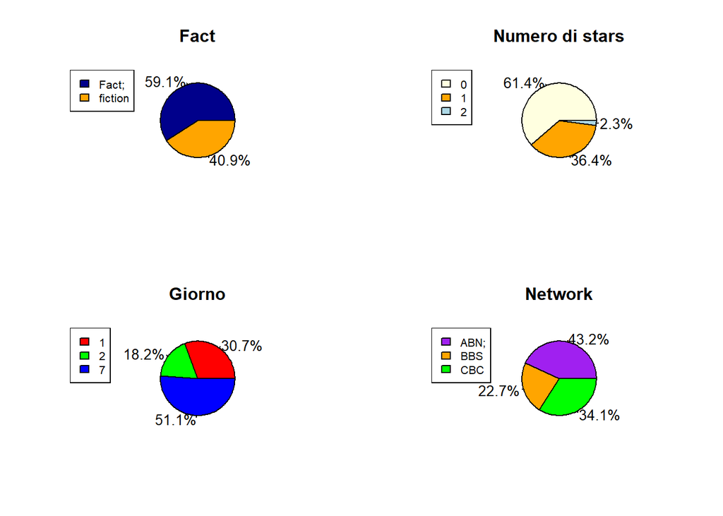

Eseguiamo alcuni plot per ricercare eventuali outliers e caratterizzare visivamente la relazione tra la variabile *rating* e i predittori.

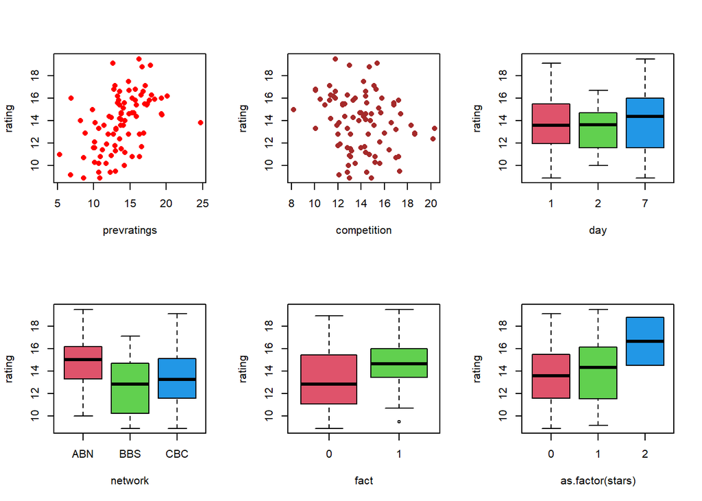

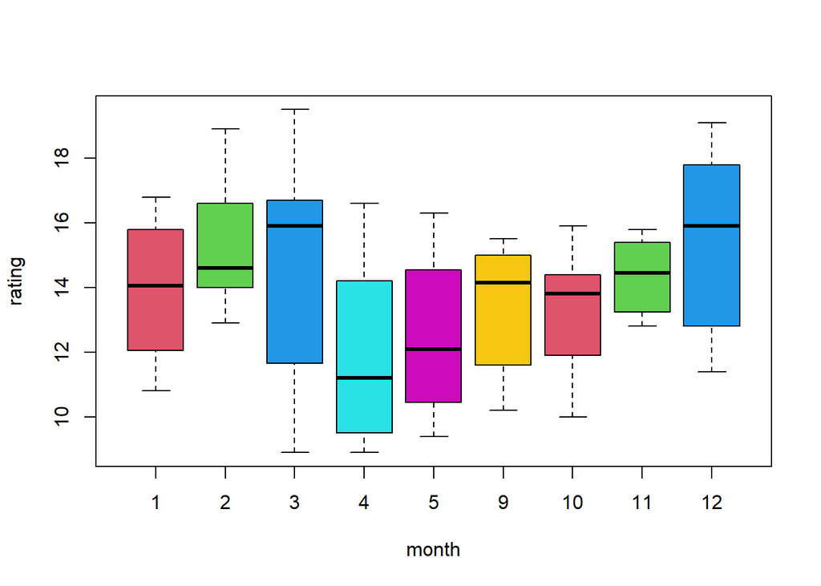

Notiamo la presenza di una osservazione particolare nel grafico di prevratings. Essa potrebbe avere un alto valore di leverage in quanto assume un valore estremo della variabile predittore *prevratings* . Tuttavia questo non determina necessariamente che l’osservazione sia influente ( analisi d’influenza) . Per il momento andiamo a verificare di quale osservazione si tratta; decideremo in un secondo momento se eliminarla dal dataset per l’analisi.

```r
which(prevratings>24)
```

```
## [1] 50
```

### Introduzione di nuove variabili

Introduciamo nuove variabili:

- Per i mesi ho scelto di introdurre nuove variabili e raggrupare i mesi i cui boxplot si sovrappongono maggiormente ( mesi 9-10, 3-12, 2-11)
- Ho introdotto la variabile *week* che tiene conto se il film viene trasmesso il giorno 7, mentre non distingue se il giorno viene trasmesso il giorno 1 oppure 2.
- Infine ho provato a trattare la variabile stars come fattore, cioè distingue tra film con stars e senza stars. Tale scelta è stata motivata anche dal fatto che nel dataset ci sono solo due osservazioni con numero di stars pari a 2.

```r
dtab$setoct = as.integer(dtab$month== 9  |  dtab$month== 10 )
dtab$mardic = as.integer(dtab$month== 3  |  dtab$month== 12 )
dtab$febnov = as.integer(dtab$month== 2  |  dtab$month== 11 )
dtab$week= as.integer(dtab$day==7)
dtab$starsfac= as.integer(dtab$stars>0)
starsfac<- as.factor(dtab$starsfac)
attach(dtab)
```

## Modelli di regressione

In questa sezione, andiamo ad esaminare alcuni semplici modelli che risultano essere maggiormente interpretabili. Non siamo dunque interessati a valutare il modello (R^2 adj o MSE), ma ci focalizziamo sul valore dei coefficienti e vedremo come essi cambiano in base all’aggiunta o meno di variabili.

```
##
## Call:
## lm(formula = rating ~ network)
##
## Residuals:
##     Min      1Q  Median      3Q     Max
## -4.7605 -1.9150 -0.0605  1.6100  5.7367
##
## Coefficients:
##             Estimate Std. Error t value Pr(>|t|)
## (Intercept)  14.7605     0.3928  37.580  < 2e-16 ***
## networkBBS   -2.0455     0.6689  -3.058  0.00298 **
## networkCBC   -1.3972     0.5913  -2.363  0.02042 *
## ---
## Signif. codes:  0 '***' 0.001 '**' 0.01 '*' 0.05 '.' 0.1 ' ' 1
##
## Residual standard error: 2.421 on 85 degrees of freedom
## Multiple R-squared:  0.1143, Adjusted R-squared:  0.09344
## F-statistic: 5.483 on 2 and 85 DF,  p-value: 0.005757
```

I coefficienti del modello appena stimato mostrano che un film trasmesso sul canale BBS ha un rating previsto inferiore di 2.04 rispetto al film trasmesso su ABN. Si ragiona in maniera analoga con il canale CBC.

Confrontiamo adesso altri due modelli:

```
## (Intercept)       fact1
##   13.246154    1.401068
```

```
## (Intercept)       fact1        week
##  12.9198465   1.4673300   0.5851028
```

Vediamo infine qualche modello che include la variabile ‘prevratings’.

```
##
## Call:
## lm(formula = rating ~ prevratings)
##
## Residuals:
##     Min      1Q  Median      3Q     Max
## -4.1777 -1.5171  0.2312  1.3664  5.7274
##
## Coefficients:
##             Estimate Std. Error t value Pr(>|t|)
## (Intercept)  8.57709    1.04922   8.175 2.34e-12 ***
## prevratings  0.38059    0.07418   5.131 1.76e-06 ***
## ---
## Signif. codes:  0 '***' 0.001 '**' 0.01 '*' 0.05 '.' 0.1 ' ' 1
##
## Residual standard error: 2.238 on 86 degrees of freedom
## Multiple R-squared:  0.2344, Adjusted R-squared:  0.2255
## F-statistic: 26.32 on 1 and 86 DF,  p-value: 1.765e-06
```

```
## (Intercept) prevratings       fact1
##   7.9046745   0.3859879   1.4620182
```

```
## (Intercept) prevratings   starsfac1
##    8.487434    0.374458    0.450744
```

La variabile prevratings sembra essere significativa.

Essa influisce positivamente sul rating previsto, determinandone nella previsione un incremento unitario di quasi 0.38.

L’aggiunta della variabile ‘fact’ ne determina un incremento del coefficiente, per cui si potrebbe pensare a una correlazione positiva.

Discorso simmetricamente opposto viene applicato a ‘prevratings’ e ‘starsfac’.

Vediamo l’ultimo modello, ottenuto con selezione esaustiva delle features.

```r
library(leaps)
regfit.full=regsubsets(rating~.,dtab, nvmax =20)
```

```
## Reordering variables and trying again:
```

```r
reg.summary=summary(regfit.full)
```

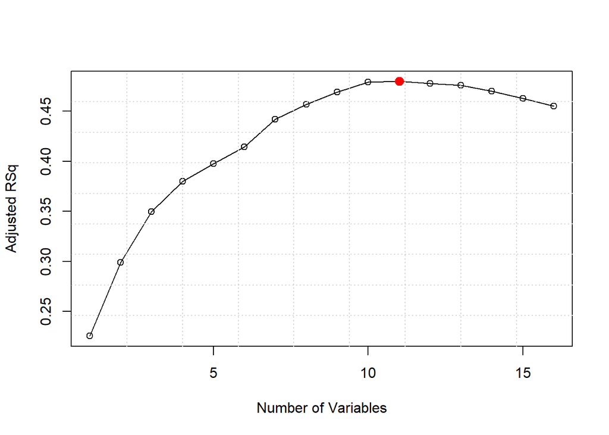

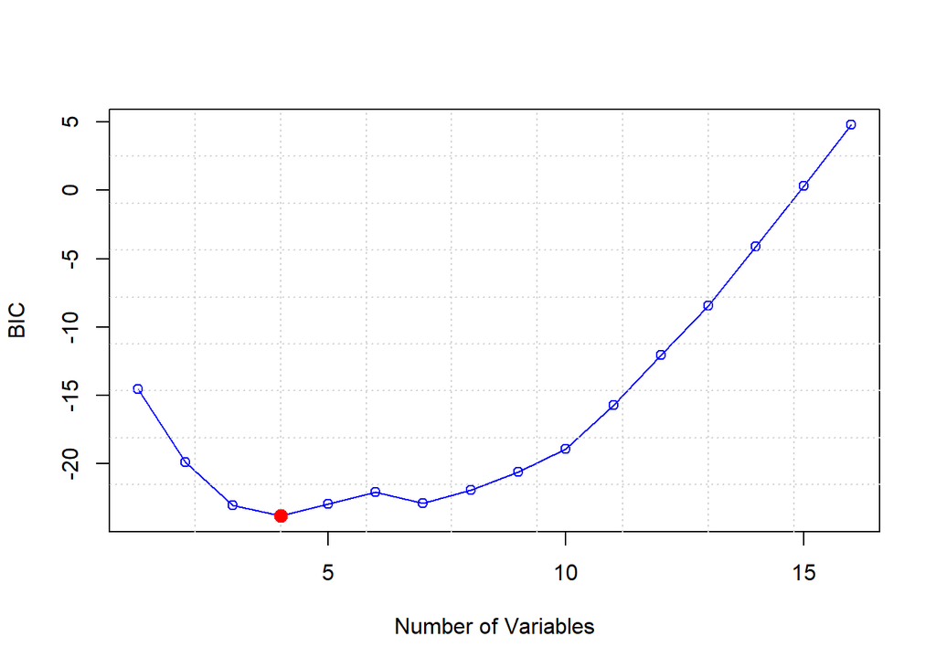

I coefficienti del modello che minimizza il BIC sono :

```
## (Intercept)        fact       stars prevratings         mon
##   7.5624918   1.7324111   0.9408857   0.3708831   0.1783220
```

Analizzando i coefficienti del modello, vediamo che un film , basato su una storia reale, ha in media, un rating maggiore di circa 1.73. Inoltre per ogni star nel film , il rating aumenta di quasi 1 punto. Anche il rating del film precedente e il fatto che il film sia trasmesso il lunedi incidono positivamente sul rating.

## Modelli di regressione con interazione

In questa sezione, analizziamo 4 diversi modelli basati su *feature selection*. Lo scopo descrittivo dei seguenti modelli giustifica l’inclusione della variabile ‘competition’ (che tiene conto del rating degli altri canali) tra i predittori. Quindi possiamo immaginare tale analisi come una analisi a posteriori in cui il valore di ‘competition’ è noto.

I modelli che vengono dati in input alle diverse funzioni di subset selection contengono anche termini di *interazioni*, a differenza dei modelli semplici ottenuti in precedenza.

### Step

Usiamo il comando *Step*, che effettua una selezione di variabile mediante una ricerca basata sulla minimizzazione del BIC (input della funzione: k = log(n), con n= numero di osservazioni).

```r
formula= rating~  (fact+starsfac+week+network+prevratings)^2+ aprmay+ aprmay:week+mardic+ competition+ mardic:week+febnov+febnov:week+setoct+ setoct:week
reg1= lm(formula)
Reg1=(step(reg1, k=log(nrow(dtab) )))
```

### Regsubsets

Utilizziamo il comando *regsubsets*, scegliendo come cardinalitá massima degli insiemi da esaminare nvamx=20.

#### Ricerca esaustiva

```r
library(leaps)
regfit.full=regsubsets(rating~(fact+starsfac+week+network+prevratings)^2+ aprmay+ aprmay:week+mardic+ competition+ mardic:week+febnov+febnov:week+setoct+ setoct:week,dtab, nvmax =20)
reg.summary=summary(regfit.full)
```

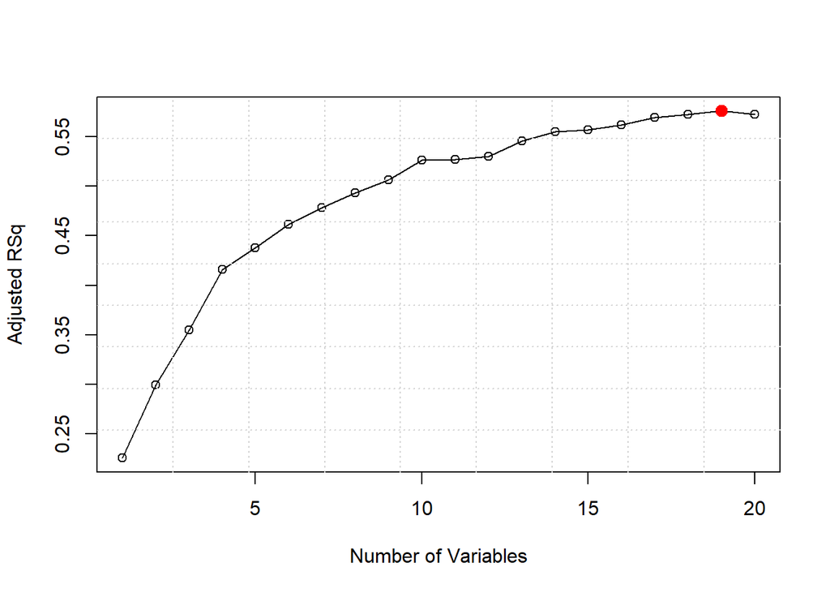

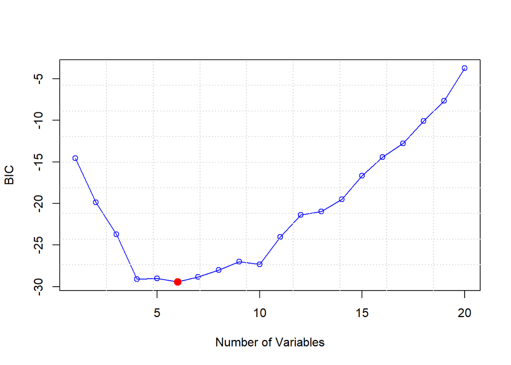

#### Forward

Vediamo i risultati con una ricerca Forward.

```r
regfit.fwd=regsubsets(rating~(fact+starsfac+week+network+prevratings+ competition)^2+ aprmay+ aprmay:week+mardic+ mardic:week+febnov+febnov:week+setoct+ setoct:week,dtab, nvmax =20, method="forward")
```

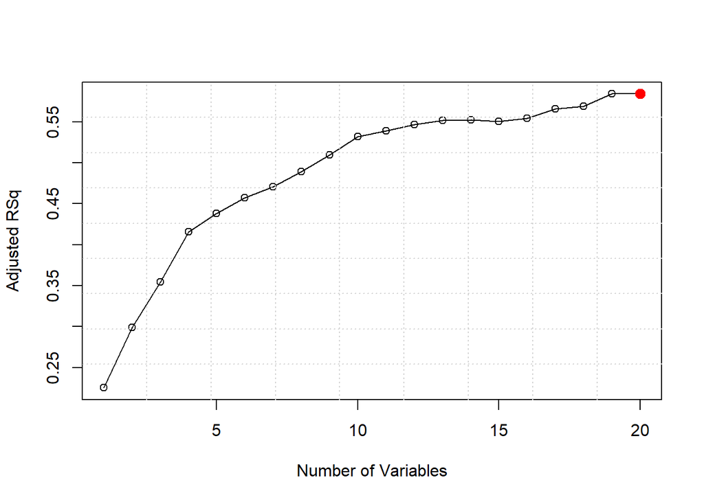

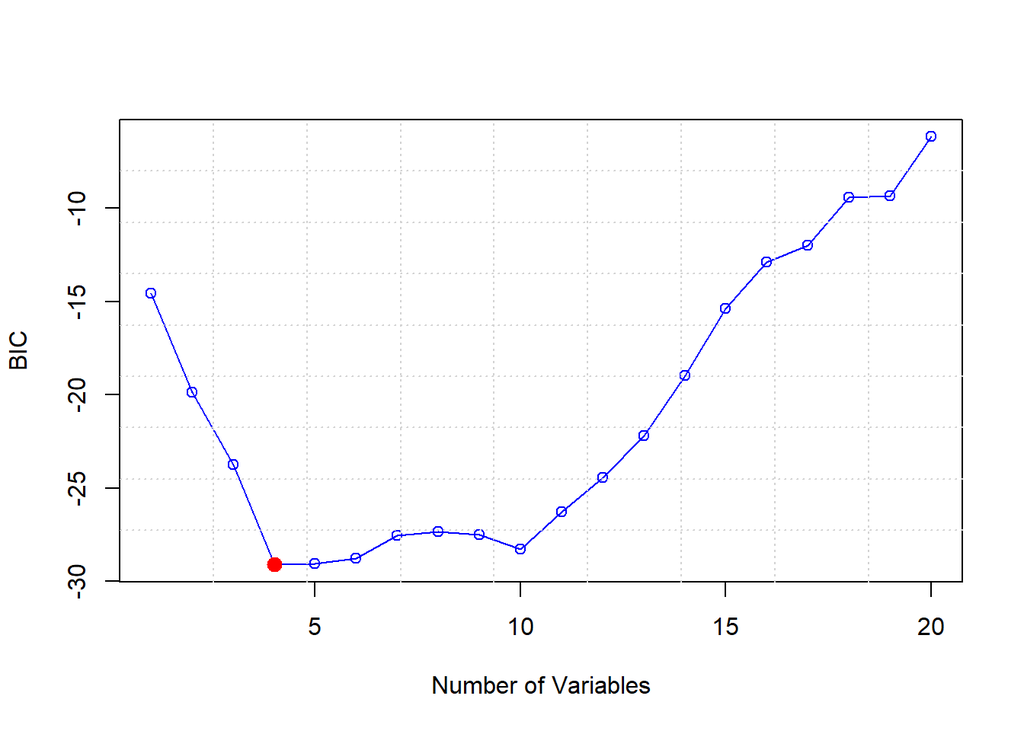

#### Backward

E infine il metodo backward.

```r
regfit.bwd=regsubsets(rating~(fact+starsfac+week+network+prevratings+ competition)^2+ aprmay+ aprmay:week+mardic+ mardic:week+febnov+febnov:week+setoct+ setoct:week,dtab, nvmax =20, method="backward")
```

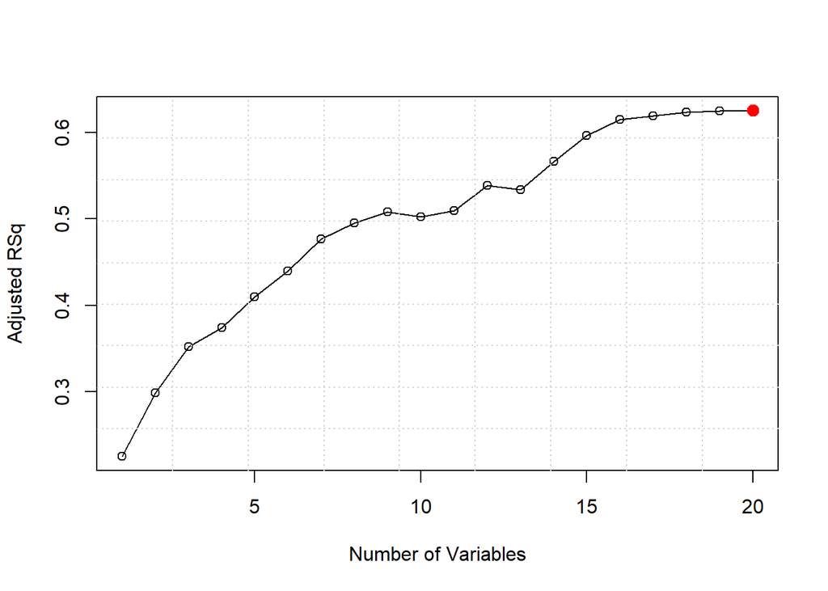

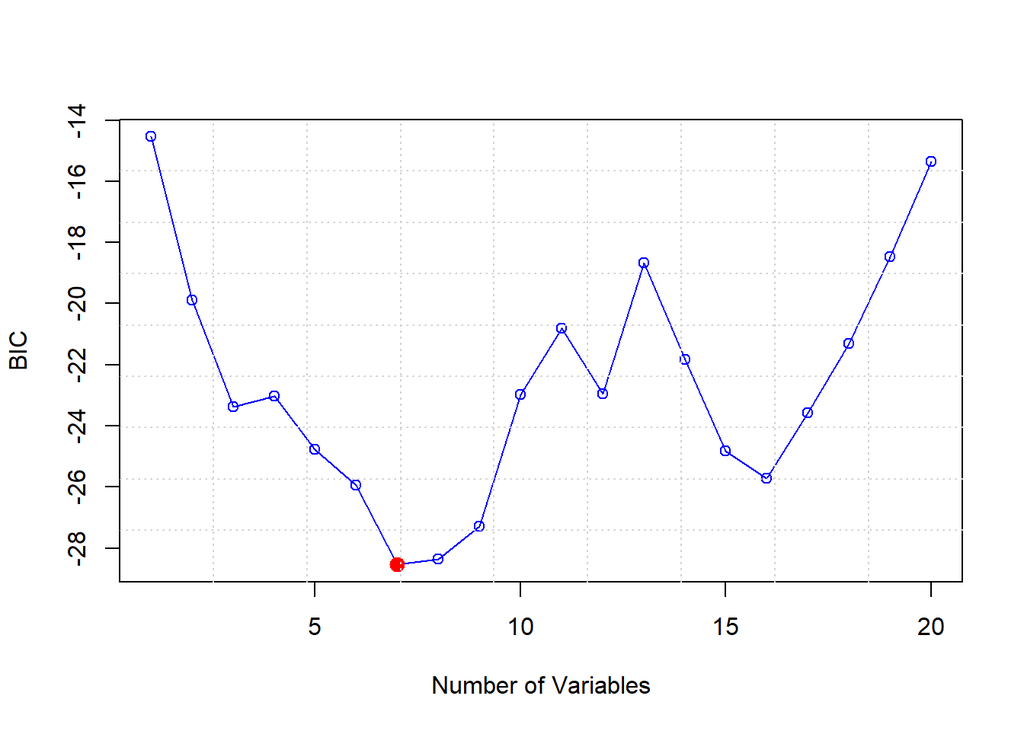

Per ogni modello, scegliamo il modello che minimizza il Bic.

Vediamo i coefficienti dei quattro modelli stimati fino ad adesso.

Primo modello con funzione step

```
##       (Intercept)             fact1       prevratings            mardic
##         5.6978861         7.1075957         0.5209782         1.3549216
## fact1:prevratings
##        -0.4056113
```

Secondo modello con subset selection (ricerca esaustiva )

```
##      (Intercept)             fact      prevratings fact:prevratings
##        6.6305560        6.8124733        0.4430267       -0.3563304
##    starsfac:week  week:networkBBS      week:mardic
##        1.3204106       -1.4744704        1.7147560
```

Terzo modello con subset selection (ricerca forward )

```
##      (Intercept)             fact      prevratings fact:prevratings
##        5.8868832        7.1672252        0.5141730       -0.4148905
##      week:mardic
##        2.1138624
```

Quarto modello con subset selection (ricerca backward )

```
##             (Intercept)                    fact             prevratings
##              3.31683794             10.23577238              0.92961824
##         fact:networkCBC        fact:prevratings           starsfac:week
##             -2.41365240             -0.55259386              1.35140277
##  networkCBC:competition prevratings:competition
##              0.16379949             -0.02194751
```

Confrontiamo ( tramite BIC e r^2 adjusted ) i 3 modelli ottenuti tramite subset selection e il primo modello ottenuto con STEP.

```
##              Mod RsquaredAdj       Bic Numero_features
## 1       Reg_step   0.3960319 391.34266              10
## 2     Reg_subset   0.4616198 -29.43578               6
## 3 Reg_subset_for   0.4160713 -29.49718               4
## 4 Reg_subset_bac   0.4765893 -28.53310               7
```

Quello che salta all’occhio, guardando la tabella, è il valore di BIC del primo modello. Effettivamente il calcolo del BIC tramite il comando BIC ( che ho usato per il primo modello) differisce da quello usato dalla libreria Leaps (quindi non possiamo confrontare direttamente i valori in tabella). Per ovviare a questo problema, cerco di ottenere il primo modello, utilizzando il comando regsubset.

```r
 Reg1_sub= regsubsets(rating~fact+prevratings+mardic+ fact:prevratings, dtab, nvmax = 20)
```

Proviamo che i due modelli stimati con STEP e regsubsets siano effettivamente lo stesso modello.

```r
coef(Reg1)
```

```
##       (Intercept)             fact1       prevratings            mardic
##         5.6978861         7.1075957         0.5209782         1.3549216
## fact1:prevratings
##        -0.4056113
```

```r
coef(Reg1_sub,4)
```

```
##      (Intercept)             fact      prevratings           mardic
##        5.6978861        7.1075957        0.5209782        1.3549216
## fact:prevratings
##       -0.4056113
```

Dopo questa verifica, calcoliamo il BIC del primo modello.

```r
BIC(Reg1) #inserito nella tabella precedente
```

```
## [1] 391.3427
```

```r
summary(Reg1_sub)$bic[4]
```

```
## [1] -26.12784
```

Come ci aspettavamo i due valori sono diversi, seppure riferiti allo stesso modello ( indice del fatto che i due comandi utilizzato un diverso calcolo per il BIC). Adesso aggiorniamo la tabella con il valore corretto.

```
##              Mod RsquaredAdj       Bic Numero_predittori
## 1       Reg_step   0.3960319 -26.12784                10
## 2     Reg_subset   0.4616198 -29.43578                 6
## 3 Reg_subset_for   0.4160713 -29.49718                 4
## 4 Reg_subset_bac   0.4765893 -28.53310                 7
```

I quattro modelli finora stimati sono accomunati dalla presenza di tre features, che si confermano quindi essere decisive nella previsione del rating. Esse sono *fact*, *prevratings* e il termine di interazione tra *fact* e *prevratings*.

Inoltre, vediamo come il ruolo di ‘competition’ non sembra essere centrale nella determinazione del rating. Infatti solo in una di esse viene selezionata la variabile competition. Quindi potremmo pensare di utilizzare i modelli in cui la variabile ‘competition’ non è inserita anche sotto le ipotesi in cui il valore di competition non è noto.

Il modello miglior dal punto di vista del BIC è il terzo, mentre il migliore valore di RsquaredAdj è ottenuto nel quarto modello.

Infine notiamo che i modelli stimati violano il principio gerarchico della regressione in quanto presentano alcuni termini di interazione, pur non prendendo in considerazione le variabili dell’effetto singolo.

Cerchiamo di capire cosa cambia l’aggiunta degli effetti singoli. Quindi consideriamo (per una questione di semplicità) il terzo modello e aggiungiamo manualmente le variabili singole che mancano.

##### Terzo modello

```
##
## Call:
## lm(formula = rating ~ fact + prevratings + week:mardic + fact:prevratings)
##
## Residuals:
##     Min      1Q  Median      3Q     Max
## -4.8448 -1.2483 -0.1025  1.0683  4.7949
##
## Coefficients:
##                   Estimate Std. Error t value Pr(>|t|)
## (Intercept)        5.88688    1.17216   5.022 2.88e-06 ***
## fact1              7.16723    1.86691   3.839  0.00024 ***
## prevratings        0.51417    0.08276   6.212 1.98e-08 ***
## week:mardic        2.11386    0.66198   3.193  0.00199 **
## fact1:prevratings -0.41489    0.13234  -3.135  0.00238 **
## ---
## Signif. codes:  0 '***' 0.001 '**' 0.01 '*' 0.05 '.' 0.1 ' ' 1
##
## Residual standard error: 1.943 on 83 degrees of freedom
## Multiple R-squared:  0.4429, Adjusted R-squared:  0.4161
## F-statistic:  16.5 on 4 and 83 DF,  p-value: 5.534e-10
```

##### Terzo modello dopo l’aggiunta delle variabili

```
##
## Call:
## lm(formula = rating ~ fact + prevratings + week + mardic + week:mardic +
##     fact:prevratings)
##
## Residuals:
##    Min     1Q Median     3Q    Max
## -4.751 -1.177 -0.171  1.166  4.290
##
## Coefficients:
##                   Estimate Std. Error t value Pr(>|t|)
## (Intercept)        5.77539    1.21189   4.766 8.16e-06 ***
## fact1              7.24071    1.89388   3.823 0.000258 ***
## prevratings        0.51224    0.08345   6.138 2.93e-08 ***
## week               0.09826    0.48414   0.203 0.839681
## mardic             0.59642    0.71464   0.835 0.406414
## week:mardic        1.54534    1.00450   1.538 0.127844
## fact1:prevratings -0.41723    0.13381  -3.118 0.002520 **
## ---
## Signif. codes:  0 '***' 0.001 '**' 0.01 '*' 0.05 '.' 0.1 ' ' 1
##
## Residual standard error: 1.959 on 81 degrees of freedom
## Multiple R-squared:  0.4477, Adjusted R-squared:  0.4068
## F-statistic: 10.95 on 6 and 81 DF,  p-value: 6.759e-09
```

L’aggiunta di nuove variabili determina senz’altro un decremento, seppur minimo ( pari a 0.0093), del valore di *Adjusted r-squared*. Inoltre le variabili singole risultano nel modello completo non significative. Tuttavia il modello, seppur ‘peggiore’ in termini di previsione, risulta maggiormente interpretrabile. Diamo alcuni esempi di interpretazione:

- a paritá dei valori delle altre variabili di regressione, un film basato sulla realtá (fact=1) ha un rating previsto di 7.24017 - 0.41723* $x_{prevratings}$ maggiore di un film con la variabile fact=0.
- a paritá della altre variabili, un film trasmesso durante il week-end ha un rating previsto maggiore di 0.09826 rispetto al film trasmesso non nel week-end ( week=0). A questo incremento si aggiunge +1.54534 se il film viene trasmesso nei mesi di marzo e dicembre (mardic=1).

#### Cross validation e Regsubsets

##### K=20

Adesso utilizziamo il comando *regsubsets* (ricerca esaustiva) unito alla cross validation (numero di folds k=20).

Vediamo gli errori calcolati sul dataset test in funzione del numero di regressori usati.

```
##        1        2        3        4        5        6        7        8
## 4.873600 4.902921 5.062793 4.615591 4.326143 4.030840 3.943279 4.055800
##        9       10       11       12       13       14       15       16
## 4.417190 4.047447 4.380696 4.613977 4.608364 4.594574 4.818064 4.846538
##       17       18       19       20
## 4.853234 4.941937 5.010755 5.003310
```

Come accade generalmente, l’errore calcolato sul dataset test aumenta all’aumentare del numero di predittori usati per stimare il modello (overfitting), mentre l’errore sul training data ha un andamento monotono decrescente.

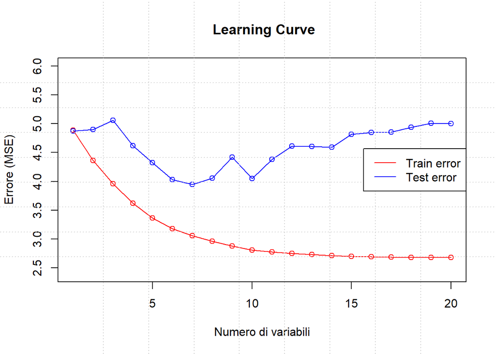

Scegliamo il modello con il minimo errore di test e vediamone i coefficienti:

```
##      (Intercept)             fact      prevratings           mardic
##        6.6024735        6.4278223        0.4400629        1.2877341
##    fact:starsfac fact:prevratings    starsfac:week  competition:bbs
##        1.6440000       -0.3518694        1.2507610       -0.0725336
```

Il BIC del modello vale

```
## [1] -26.79595
```

$R^2$adj vale

```
## [1] 0.4661544
```

Questi valori possono essere confrontati con i modelli ottenuti in precedenza.

##### Leave-one-out

Eseguiamo una cross-validation leave one out, quindi K= #osservazioni. Scelta motivata dal fatto che il numero di osservazioni del dataset è esiguo.

Vediamo gli errori calcolati sul dataset test in funzione del numero di regressori usati.

```
##        1        2        3        4        5        6        7        8
## 5.169679 5.025930 5.813411 5.461646 4.708472 4.453246 4.472650 4.235464
##        9       10       11       12       13       14       15
## 4.212796 3.919900 4.402443 4.694561 4.647014 4.569995 4.856858
```

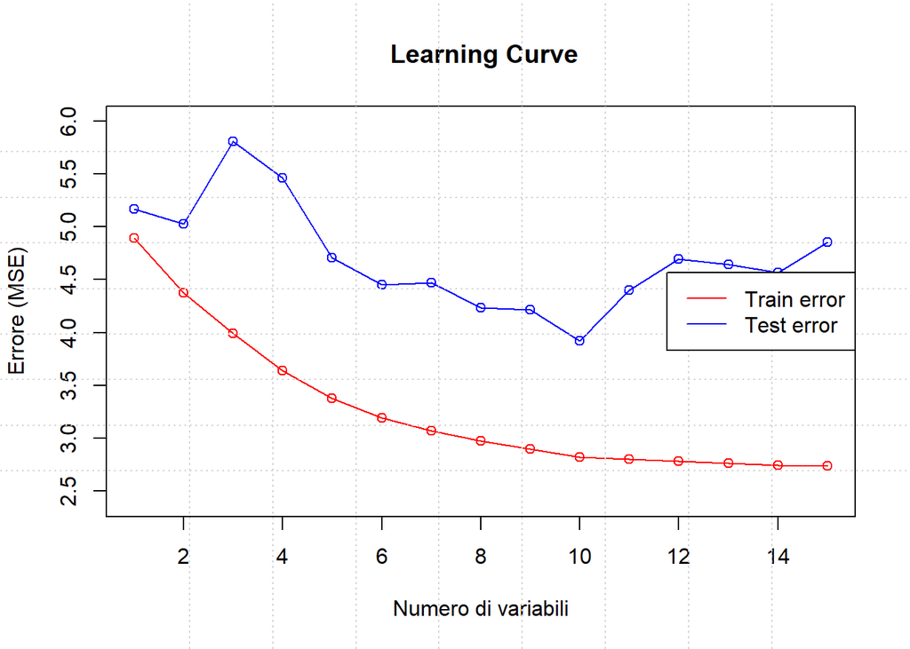

Scegliamo il modello con il minimo errore di test e vediamone i coefficienti:

```
##      (Intercept)             fact      prevratings              bbs
##        5.9003120        6.9443380        0.5163853        3.0264413
##              abn           mardic    fact:starsfac fact:prevratings
##        5.1978939        1.1649546        1.7482906       -0.4044244
##    starsfac:week  competition:bbs  competition:abn
##        1.0766395       -0.2918470       -0.4392950
```

Il BIC del modello vale

```
## [1] -21.92395
```

$R^2$adj vale

```
## [1] 0.4967661
```

I modelli stimati stimati tramite cross-validation performano in maniera simile: la maggior parte dei predittori risulta comune, il primo modello sembra essere migliore in termini di BIC, mentre il secondo in termini di $R^2adj$.

## Regressione e metodi di regolarizzazione

### Ridge Regression

Utilizziamo il pacchetto **glmnet** per performare **ridge regressione** e **lasso**. Il parametro α che la funzione riceve in input serve per specificare che tipo di regressione si vuole performare (α=0 per ridge regression e α=1 per lasso). Scegliamo di effettuare le regressioni , per valori di λ compresi tra 10^10 e 10^-2.

In questo modo copriamo tutti i possibili modelli, a partire da quello nullo che contiene solo l’intercetta fino al classico modello ottenuto con il metodo dei minimi quadrati.

Dividiamo il dataset in un training set e un test set in modo da stimare l’errore test delle regressioni. In particolare, otteniamo un dataset test di 21 osservazioni e un dataset train di 67 osservazioni.

```r
x=model.matrix(rating~((fact+week+prevratings+starsfac+  network + setoct+ march+ dec))^2+ I((prevratings)^2)+competition+I((competition)^2) , dtab)[,-1]
```

Andiamo a vedere quale è il test MSE del modello con solo l’intercetta , in cui per ogni osservazione del test prediciamo un valore che è la media delle osservazioni del train.

```r
mean((mean(y[train])-y.test)^2)
```

```
## [1] 5.21562
```

Confrontiamo con il valore che otteniamo con quello di ridge regressione con un valore molto grande di λ.

```r
ridge.pred=predict(ridge.mod,s=1e10,newx=x[test,])
mean((ridge.pred-y.test)^2)
```

```
## [1] 5.21562
```

Come ci aspettavamo, abbiamo ottenuto lo stesso risultato. Infatti più è alto il valore di λ più rilevante è la penalizzazione dei coefficienti. Di conseguenza il modello stimato è quello con la sola intercetta ( unico parametro non penalizzato).

Adesso utilizziamo la cross validation ( sul train ) per scegliere il parametro λ in modo da minimizzare l’errore.

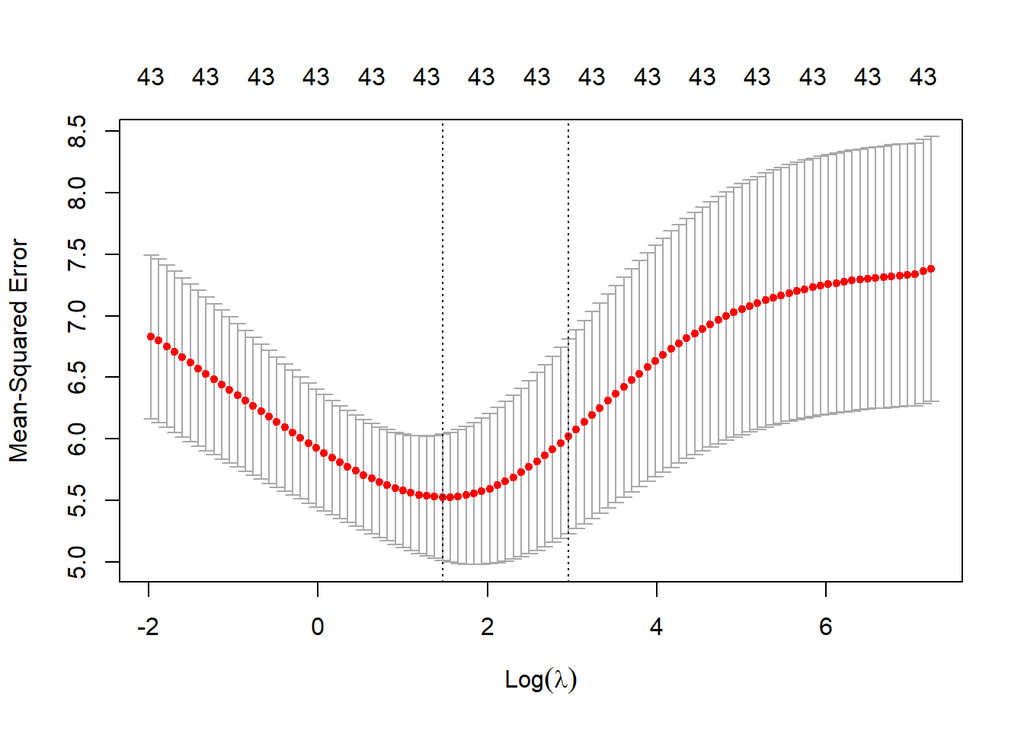

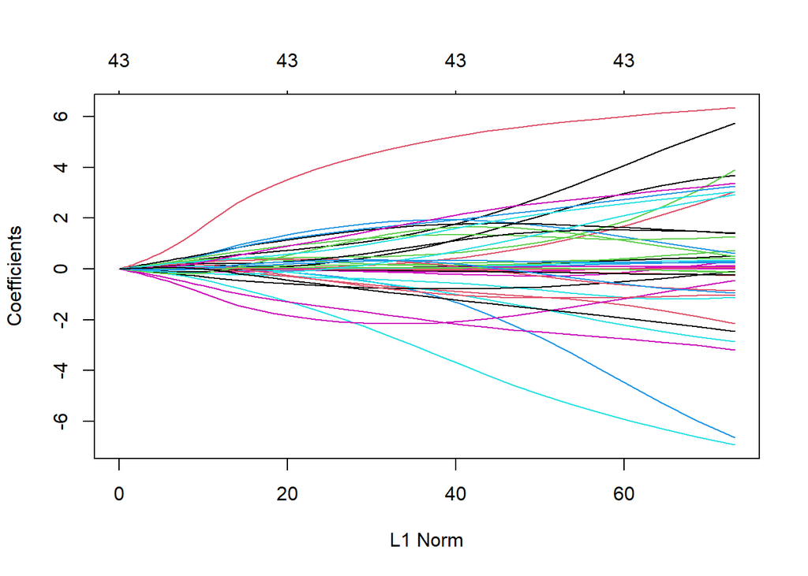

Grazie alla cross validation, otteniamo che il miglior valore di λ è

```
## [1] 4.34856
```

L’errore test MSE associato a questo valore è

```
## [1] 4.192572
```

Adesso, fittiamo il modello sull’intero dataset train e usando il valore di λ scelto grazie alla cross-validation.

Esaminiamo i valori dei coefficienti

```
##        (Intercept)               fact               week        prevratings
##       12.547119344        0.360826761        0.033576375        0.076771812
##           starsfac         networkBBS         networkCBC             setoct
##        0.120635422       -0.268224546       -0.041169777       -0.039307749
##              march                dec I((prevratings)^2)        competition
##       -0.009798982        0.371285513        0.002336624       -0.046086591
## I((competition)^2)          fact:week   fact:prevratings      fact:starsfac
##       -0.001433027        0.232107341        0.019718804        0.593315335
##    fact:networkBBS    fact:networkCBC        fact:setoct         fact:march
##        0.313383909        0.112552927        0.049924545        0.672275339
```

### Lasso Regression

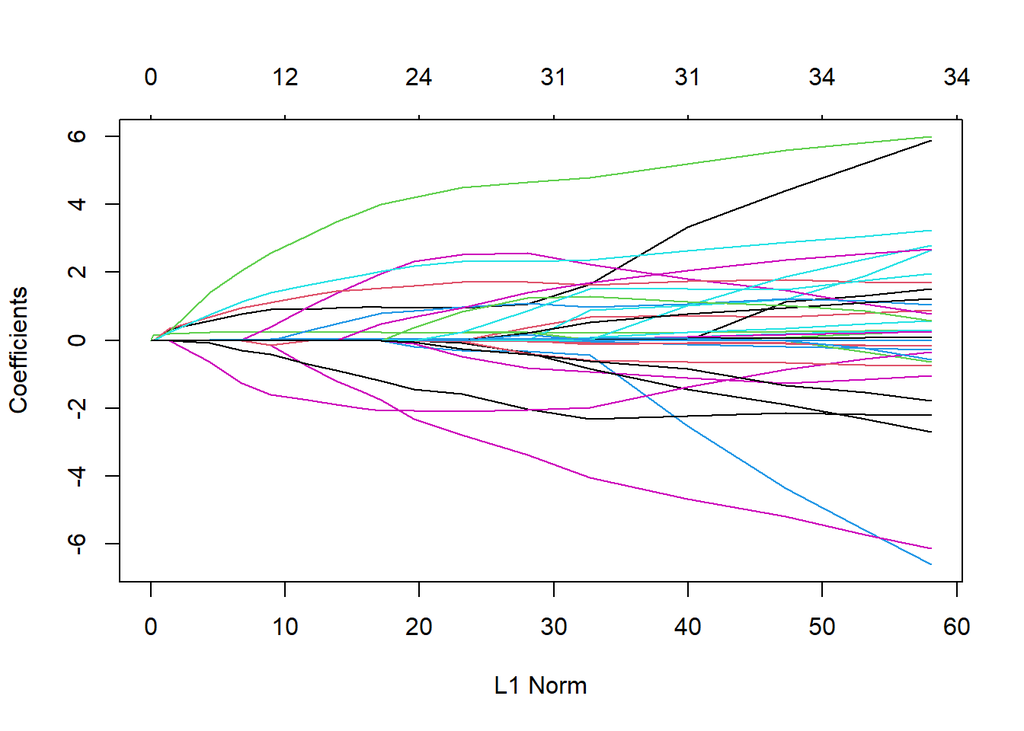

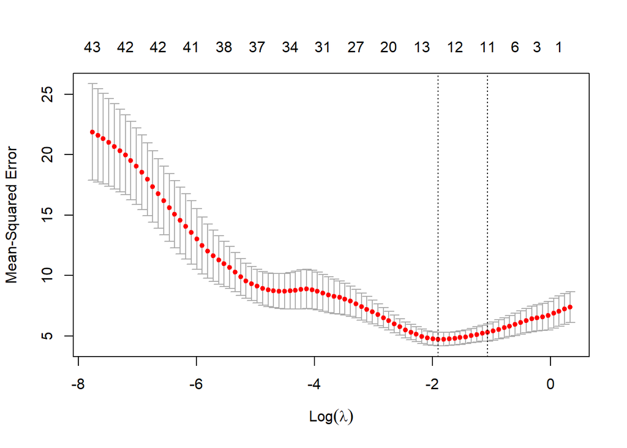

Il valore di λ scelto dalla cross-validation è

```
## [1] 0.149176
```

L’errore risulta essere

```
## [1] 4.664496
```

Confrontando i valori ottenuti di TEST MSE delle regressioni, il modello migliore si ottiene con la regressione Ridge. La regressione *Lasso*, a differenza di quella *Ridge* opera una selezione delle features (in quanto alcuni coefficienti della regressione che si ottengono sono nulli).

Nel nostro caso, i coefficienti non nulli della regressione lasso sono i seguenti:

```
##     (Intercept)            fact     prevratings     competition   fact:starsfac
##     10.42220000      0.98315980      0.27065444     -0.08346843      1.06180106
## fact:networkBBS
##      0.13135897
```

A differenza, di quello che accade per feature selection, con i metodi di regressione la variabile competition viene sempre selezionata. Proviamo a ripetere l’analisi eliminando tale variabile.

### Esclusione della variabile ‘competition’

Come prima, ricerchiamo i valori ottimali per λ

Riportiamo solo alcuni risultati principali.

Ridge Regression

```r
x=model.matrix(rating~((fact+week+prevratings+starsfac+  network + setoct+ march+ dec))^2+ I((prevratings)^2) , dtab)[,-1]
```

L’errore test MSE associato a questo valore è

```
## [1] 4.328778
```

Esaminiamo i valori dei coefficienti

```
##        (Intercept)               fact               week        prevratings
##       11.608803429        0.356457705        0.053231632        0.077326251
##           starsfac         networkBBS         networkCBC             setoct
##        0.117383672       -0.282119105       -0.079062772       -0.041256390
##              march                dec I((prevratings)^2)          fact:week
##       -0.001223290        0.383592840        0.002355504        0.259583058
##   fact:prevratings      fact:starsfac    fact:networkBBS    fact:networkCBC
##        0.019639420        0.582007711        0.317408547        0.065783420
##        fact:setoct         fact:march           fact:dec   week:prevratings
##        0.057282097        0.679404020        1.742982841        0.013920825
```

Lasso Regression

Il test MSE risulta essere

```
## [1] 4.689796
```

Nel nostro caso, i coefficienti non nulli della regressione lasso sono i seguenti:

```
##     (Intercept)            fact     prevratings      networkBBS       fact:week
##      9.10978936      0.93784548      0.28021042     -0.01540091      0.06624884
##   fact:starsfac fact:networkBBS
##      1.03660024      0.22250276
```

L’eliminazione di competition dai regressori ha determinato:

- un aumento del numero di features selezionate nella regressione Lasso
- un peggioramento, seppur minimo, del test MSE in entrambe le regressioni regolarizzate.

## Scelta del modello

Continuiamo l’analisi del terzo modello ottenuto dalla feature selection (aggiornato dopo l’aggiunta delle variabili. )

### Analisi d’influenza

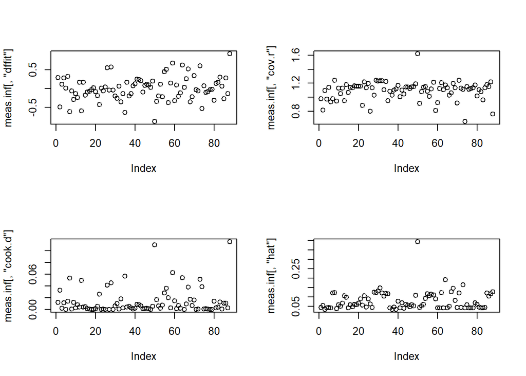

```r
meas.inf = influence.measures(modello3_update)$infmat
par(mfrow=c(2,2))
plot(meas.inf[,"dffit"])
plot(meas.inf[,"cov.r"])
plot(meas.inf[,"cook.d"])
plot(meas.inf[,"hat"])
```

Non ci sono osservazioni particolarmente influenti: tutte le osservazioni hanno una distanza di Cook minore di 1. Tuttavia notiamo una osservazione che in tutti i grafici riportati si discosta particolarmente dalle altre osservazioni. Verifichiamo di quale osservazione si tratta e, dopo averla eliminata dal dataset, stimiamo il modello.

```r
which(meas.inf[,"cook.d"]>0.08 & (meas.inf[,"cov.r"]>1.5 & meas.inf[,"hat"]>0.25) )
```

```
## 50
## 50
```

```r
dtab <- dtab[-50,]
```

Effettivamente, si tratta della osservazione che ad inizio analisi era stata identificata come potenziale outlier. Eliminiamola dal dataset e fittiamo di nuovo il modello.

```r
modello3_update= lm(rating~ fact+ prevratings+ week+ mardic+ week:mardic+ fact:prevratings, data=dtab)
summary(modello3_update)
```

```
##
## Call:
## lm(formula = rating ~ fact + prevratings + week + mardic + week:mardic +
##     fact:prevratings, data = dtab)
##
## Residuals:
##     Min      1Q  Median      3Q     Max
## -4.7637 -1.2117 -0.0176  1.1852  4.3295
##
## Coefficients:
##                  Estimate Std. Error t value Pr(>|t|)
## (Intercept)       5.74886    1.21074   4.748 8.87e-06 ***
## fact              6.15305    2.13884   2.877  0.00515 **
## prevratings       0.51354    0.08336   6.160 2.76e-08 ***
## week              0.14664    0.48561   0.302  0.76345
## mardic            0.57947    0.71398   0.812  0.41943
## week:mardic       1.42218    1.00968   1.409  0.16284
## fact:prevratings -0.33186    0.15492  -2.142  0.03522 *
## ---
## Signif. codes:  0 '***' 0.001 '**' 0.01 '*' 0.05 '.' 0.1 ' ' 1
##
## Residual standard error: 1.956 on 80 degrees of freedom
## Multiple R-squared:  0.4558, Adjusted R-squared:  0.415
## F-statistic: 11.17 on 6 and 80 DF,  p-value: 5.098e-09
```

### Analisi dei residui

Infine analizziamo i residui del modello.

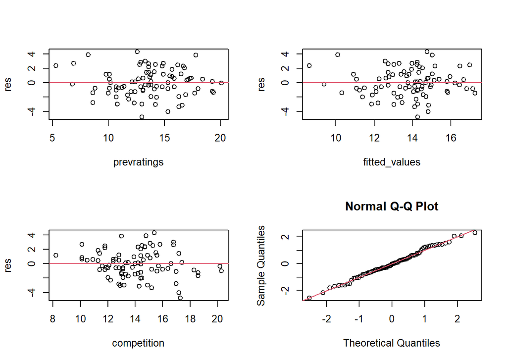

Nei primi tre grafici non sembrano esserci patterns evidenti, per cui le ipotesi alla base del modello di regressione lineare sono rispettate (linearitá omoschedasticitá, indipendenza tra residui e variabili).

L’ultimo grafico di destra mostra i quantili dei residui messi a confronto con quelli della distribuzione normale di una variabile teorica con la stessa media e la stessa deviazione standard. Dato che i punti si dispongono approssimativamente lungo la diagonale del grafico, l’ipotesi di normalitá dei residui alla base del modello di regressione non viene violata.